# Airbnb Price Prediction

Mihai-Bogdan Bîndilă 3264424

### Problem description

The number of Airbnb listings has recorded a [steady increase](https://www.businessofapps.com/data/airbnb-statistics/), from 300,000 in 2013 to 7.7 million in 2023. Hence, this project aims to leverage this rich data to identify key factors influencing nightly rental prices. With a focus on Amsterdam as a case study, we will build a predictive regression model to estimate these prices. The developed model will be integrated into a web application designed for owners. They will be empowered to gain insights into optimal pricing strategies based on property characteristics and potential guest ratings.

### Data description

It contains the following features that can be used to predict the price per night (realSum):  
**- property characteristics:** type of room, private or shared, capacity, number of bedrooms, for business purposes or not  
**- data from Tripadvisor:** accessibility to attractions and restaurants within the neighborhood of the property  
**- location:** longitude, latitude, distance from the city center and from the nearest metro station  
**- ratings:** cleanliness and guest satisfaction scores  
**- host:** is super host or not

```r
# load the CSV files, combine them into one data frame and store for later use in the Shiny Application
data_weekdays <- read_delim(
  file = "./data/amsterdam_weekdays.csv",
  delim = ",",
  col_names = TRUE,
  show_col_types = FALSE
)
data_weekends <- read_delim(
  file = "./data/amsterdam_weekends.csv",
  delim = ",",
  col_names = TRUE,
  show_col_types = FALSE
)
complete_data <- bind_rows(data_weekdays, data_weekends)
write.csv(complete_data, file = "./airbnb_price_prediction/www/amsterdam_raw.csv", row.names = FALSE)
complete_data
```

| index | realSum | room_type | room_shared | room_private | person_capacity | host_is_superhost | multi | biz | cleanliness_rating | guest_satisfaction_overall | bedrooms | dist | metro_dist | attr_index | attr_index_norm | rest_index | rest_index_norm | lng | lat |
| --- | --- | --- | --- | --- | --- | --- | --- | --- | --- | --- | --- | --- | --- | --- | --- | --- | --- | --- | --- |
| 0 | 194.0337 | Private room | FALSE | TRUE | 2 | FALSE | 1 | 0 | 10 | 93 | 1 | 5.02296380 | 2.53938000 | 78.69038 | 4.166708 | 98.25390 | 6.846473 | 4.90569 | 52.41772 |
| 1 | 344.2458 | Private room | FALSE | TRUE | 4 | FALSE | 0 | 0 | 8 | 85 | 1 | 0.48838929 | 0.23940392 | 631.17638 | 33.421209 | 837.28076 | 58.342928 | 4.90005 | 52.37432 |
| 2 | 264.1014 | Private room | FALSE | TRUE | 2 | FALSE | 0 | 1 | 9 | 87 | 1 | 5.74831192 | 3.65162129 | 75.27588 | 3.985908 | 95.38695 | 6.646700 | 4.97512 | 52.36103 |
| 3 | 433.5294 | Private room | FALSE | TRUE | 4 | FALSE | 0 | 1 | 9 | 90 | 2 | 0.38486201 | 0.43987608 | 493.27253 | 26.119108 | 875.03310 | 60.973565 | 4.89417 | 52.37663 |
| 4 | 485.5529 | Private room | FALSE | TRUE | 2 | TRUE | 0 | 0 | 10 | 98 | 1 | 0.54473818 | 0.31869265 | 552.83032 | 29.272733 | 815.30574 | 56.811677 | 4.90051 | 52.37508 |
| 5 | 552.8086 | Private room | FALSE | TRUE | 3 | FALSE | 0 | 0 | 8 | 100 | 2 | 2.13142008 | 1.90466824 | 174.78896 | 9.255191 | 225.20166 | 15.692376 | 4.87699 | 52.38966 |
| 6 | 215.1243 | Private room | FALSE | TRUE | 2 | FALSE | 0 | 0 | 10 | 94 | 1 | 1.88109156 | 0.72974674 | 200.16765 | 10.599010 | 242.76552 | 16.916251 | 4.91570 | 52.38296 |
| 7 | 2771.3074 | Entire home/apt | FALSE | FALSE | 4 | TRUE | 0 | 0 | 10 | 100 | 3 | 1.68680697 | 1.45840357 | 208.80811 | 11.056528 | 272.31382 | 18.975219 | 4.88467 | 52.38749 |
| 8 | 1001.8044 | Entire home/apt | FALSE | FALSE | 4 | FALSE | 0 | 0 | 9 | 96 | 2 | 3.71914140 | 1.19611235 | 106.22646 | 5.624761 | 133.87620 | 9.328686 | 4.86459 | 52.40175 |
| 9 | 276.5215 | Private room | FALSE | TRUE | 2 | FALSE | 1 | 0 | 10 | 88 | 1 | 3.14236143 | 0.92440444 | 206.25286 | 10.921226 | 238.29126 | 16.604478 | 4.87600 | 52.34700 |

[output cut: 2070 more lines]

### Data inspection and preprocessing

The dataset has **2,080 rows** and **20 columns**.

The first step is to increase the readability by renaming the features with more meaningful names

```r
# rename features so that their name is more meaningful
complete_data <- rename(
  complete_data,
  price = realSum,
  business_room = biz,
  is_superhost = host_is_superhost,
  multiple_rooms = multi,
  satisfaction_rating = guest_satisfaction_overall,
  center_dist = dist,
  attractions_index = attr_index_norm,
  restaurants_index = rest_index_norm,
  longitude = lng,
  latitude = lat,
  capacity = person_capacity,
  bedrooms_no = bedrooms
)
```

The second step needed for the inspection is represented by the factorization of categorical columns.

```r
# factor the categorical features
complete_data <- complete_data %>%
  mutate(room_type = factor(room_type)) %>%
  mutate(room_shared = factor(room_shared)) %>%
  mutate(room_private = factor(room_private)) %>%
  mutate(capacity = factor(capacity)) %>%
  mutate(is_superhost = factor(is_superhost)) %>%
  mutate(multiple_rooms = factor(multiple_rooms)) %>%
  mutate(business_room = factor(business_room)) %>%
  mutate(bedrooms_no = factor(bedrooms_no))
```

After that, we can count how many features are categorical and how many are continuous.

```r
# count categorical and continuous columns
categorical_variables_no <- ncol(complete_data %>% dplyr::select(where(is.factor)))
continuous_variables_no <- ncol(complete_data %>% dplyr::select(!where(is.factor)))
```

There are **8 categorical columns** and **12 continuous columns**.

### Data cleaning

#### Missing values

After familiarizing with the data, we continue with the data cleaning process. Firstly, we look for missing values. It can be observed that there are **no missing value** in any of the columns.

```r
# count the number of missing values per column
missing_values <- complete_data %>%
  summarize(across(everything(), ~ sum(is.na(.x))))
missing_values
```

| index | price | room_type | room_shared | room_private | capacity | is_superhost | multiple_rooms | business_room | cleanliness_rating | satisfaction_rating | bedrooms_no | center_dist | metro_dist | attr_index | attractions_index | rest_index | restaurants_index | longitude | latitude |
| --- | --- | --- | --- | --- | --- | --- | --- | --- | --- | --- | --- | --- | --- | --- | --- | --- | --- | --- | --- |
| 0 | 0 | 0 | 0 | 0 | 0 | 0 | 0 | 0 | 0 | 0 | 0 | 0 | 0 | 0 | 0 | 0 | 0 | 0 | 0 |

#### Drop redundant columns

Secondly, we should remove redundant features. For example the information from **room_private** is contained in the **room_type** feature, and the columns **attr_index** and **rest_index** already have a scaled version in the dataset.

```r
# remove redundant features
data <- subset(complete_data,
               select = -c(index, attr_index, rest_index, room_private))
```

#### Consistency

In term of consistency, the categorical columns with two classes should contain the same values (TRUE and FALSE), but in our case **multiple_rooms** and **business_room** have the values 0 and 1. Last but not least, the uniformity can be maximized if the ratings from **cleanliness_rating** and **guest_satisfaction_overall** have the same scale.

```r
# make sure all binary categorical features have the values TRUE and FALSE, instead of numeric values (0 and 1)
data$multiple_rooms <- ifelse(data$multiple_rooms == 0, FALSE, TRUE)
data$business_room <- ifelse(data$business_room == 0, FALSE, TRUE)
data <- data %>%
  mutate(multiple_rooms = factor(multiple_rooms)) %>%
  mutate(business_room = factor(business_room))

# scale the cleanliness rating to have the same scale as the satisfaction rating
data$cleanliness_rating  <- data$cleanliness_rating * 10
head(data)
```

| price | room_type | room_shared | capacity | is_superhost | multiple_rooms | business_room | cleanliness_rating | satisfaction_rating | bedrooms_no | center_dist | metro_dist | attractions_index | restaurants_index | longitude | latitude |
| --- | --- | --- | --- | --- | --- | --- | --- | --- | --- | --- | --- | --- | --- | --- | --- |
| 194.0337 | Private room | FALSE | 2 | FALSE | TRUE | FALSE | 100 | 93 | 1 | 5.0229638 | 2.5393800 | 4.166708 | 6.846473 | 4.90569 | 52.41772 |
| 344.2458 | Private room | FALSE | 4 | FALSE | FALSE | FALSE | 80 | 85 | 1 | 0.4883893 | 0.2394039 | 33.421209 | 58.342928 | 4.90005 | 52.37432 |
| 264.1014 | Private room | FALSE | 2 | FALSE | FALSE | TRUE | 90 | 87 | 1 | 5.7483119 | 3.6516213 | 3.985908 | 6.646700 | 4.97512 | 52.36103 |
| 433.5294 | Private room | FALSE | 4 | FALSE | FALSE | TRUE | 90 | 90 | 2 | 0.3848620 | 0.4398761 | 26.119108 | 60.973565 | 4.89417 | 52.37663 |
| 485.5529 | Private room | FALSE | 2 | TRUE | FALSE | FALSE | 100 | 98 | 1 | 0.5447382 | 0.3186926 | 29.272733 | 56.811677 | 4.90051 | 52.37508 |
| 552.8086 | Private room | FALSE | 3 | FALSE | FALSE | FALSE | 80 | 100 | 2 | 2.1314201 | 1.9046682 | 9.255191 | 15.692376 | 4.87699 | 52.38966 |

### Data Analysis

#### Summary statistics

When it comes to summary statistics, we look first at continuous features. During this step, the bound for finding outliers is computed using the Interquartile Range. It can be observed that for features such as price, distances and indices the lower bounds are smaller than the minimum values, leading to the conclusion that their distribution is right-skewed. At this point, it is concerning that the target variable price has a wide range of outliers, between ~992 and ~8130. **Because this range is under-represented, the model’s performance will be quite low for this case.**

```r
continuous_data <- data %>% dplyr::select(!where(is.factor))
data.frame(
  feature_names = colnames(continuous_data),
  min = unlist(continuous_data %>% summarize(across(
    everything(), ~ min(.x)
  )), use.names = FALSE),
  lower_bound = unlist(continuous_data %>% summarize(across(
    everything(), ~ median(.x) - 1.5 * (quantile(.x, 0.75) - quantile(.x, 0.25))
  )), use.names = FALSE),
  mean = unlist(continuous_data %>% summarize(across(
    everything(), ~ mean(.x)
  )), use.names = FALSE),
  median = unlist(continuous_data %>% summarize(across(
    everything(), ~ median(.x)
  )), use.names = FALSE),
  upper_bound = unlist(continuous_data %>% summarize(across(
    everything(), ~ median(.x) + 1.5 * (quantile(.x, 0.75) - quantile(.x, 0.25))
  )), use.names = FALSE),
  max = unlist(continuous_data %>% summarize(across(
    everything(), ~ max(.x)
  )), use.names = FALSE)
)
```

| feature_names | min | lower_bound | mean | median | upper_bound | max |
| --- | --- | --- | --- | --- | --- | --- |
| price | 128.88711832 | -71.6788133 | 573.112795 | 460.2441825 | 992.167178 | 8130.668104 |
| cleanliness_rating | 20.00000000 | 85.0000000 | 94.658654 | 100.0000000 | 115.000000 | 100.000000 |
| satisfaction_rating | 20.00000000 | 85.5000000 | 94.514423 | 96.0000000 | 106.500000 | 100.000000 |
| center_dist | 0.01504452 | -1.0867821 | 2.825052 | 2.3299509 | 5.746684 | 11.195932 |
| metro_dist | 0.03651741 | -0.6981277 | 1.089367 | 0.8619281 | 2.421984 | 4.411915 |
| attractions_index | 2.16494144 | -8.6256812 | 14.246499 | 11.0442241 | 30.714129 | 100.000000 |
| restaurants_index | 3.54520472 | -13.2789612 | 26.097566 | 20.7677605 | 54.814482 | 100.000000 |
| longitude | 4.77550000 | 4.8349163 | 4.890472 | 4.8894300 | 4.943944 | 5.010770 |
| latitude | 52.29031000 | 52.3343050 | 52.364637 | 52.3653400 | 52.396375 | 52.423480 |

Below can be seen the number of observations with prices larger than the upper bound given by the Interquartile Range and the 99th quantile. We chose **to remove the extreme target outliers**. Otherwise, these extreme outliers (larger than the 99th quantile) will influence negatively the measured metrics of the trained model because the predictor will not be able to learn these rare observations.

```r
# count how many observations have a price larger than the bounds
upper_bound <- median(data$price) + 1.5 * (quantile(data$price, 0.75) - quantile(data$price, 0.25))
quantile_99 <- quantile(data$price, 0.99)

cat(
  paste("Number of rows with the price larger than the upper bound:"),
  nrow(data %>% dplyr::filter(price >= upper_bound)),
  "\n",
  paste(
    "Number of rows with the price larger than the 99th percentile:",
    nrow(data %>% dplyr::filter(price >= quantile_99))
  )
)
```

```
## Number of rows with the price larger than the upper bound: 207
##  Number of rows with the price larger than the 99th percentile: 21
```

```r
# remove outliers
data <- data %>% dplyr::filter(price < quantile_99)
```

For categorical features, the occurrence of each class is calculated. The **room_share feature is highly unbalanced** and there is a good chance that it is not important for predicting the price. Additionally, there are functions like room_type or bedrooms_no with underrepresented classes like shared room or 5.

```r
categorical_data <- data %>% dplyr::select(where(is.factor))

get_categorical_frequencies <- function(data, column_name) {
  categories <- as.data.frame(addmargins(table(categorical_data[[column_name]])))
  categories <- categories[1:(nrow(categories) - 1), ]

  categories_freq <- NULL
  for (index in seq(1, length(categories$Var1))) {
    category_freq <- paste(categories$Var1[index],
                           " - ",
                           round(categories$Freq[index] / nrow(data) * 100, 2),
                           "%",
                           sep = "")

    if (is.null(categories_freq)) {
      categories_freq <- category_freq
    } else {
      categories_freq <- paste(categories_freq, category_freq, sep = "    ")
    }
  }

  return (categories_freq)
}

categorial_frequencies <- NULL
for (column_name in colnames(categorical_data)) {
  current_frequencies <- as.data.frame(list(
    "feature" = column_name,
    "freq_of_classes" = get_categorical_frequencies(data, column_name)
  ))

  if (is.null(categorial_frequencies)) {
    categorial_frequencies <- current_frequencies
  } else{
    categorial_frequencies <- rbind(categorial_frequencies, current_frequencies)
  }
}

categorial_frequencies
```

| feature | freq_of_classes |
| --- | --- |
| room_type | Entire home/apt - 53.67% Private room - 45.85% Shared room - 0.49% |
| room_shared | FALSE - 99.51% TRUE - 0.49% |
| capacity | 2 - 60.47% 3 - 6.75% 4 - 30.26% 5 - 0.87% 6 - 1.65% |
| is_superhost | FALSE - 71.59% TRUE - 28.41% |
| multiple_rooms | FALSE - 71.64% TRUE - 28.36% |
| business_room | FALSE - 89.36% TRUE - 10.64% |
| bedrooms_no | 0 - 7.09% 1 - 65.61% 2 - 20.69% 3 - 5.83% 4 - 0.58% 5 - 0.19% |

### Data visualization

#### Univariate visualizations

It can be observed that the original price distribution that includes outliers is right skewed. Previously there were removed the outliers larger than the second vertical line.

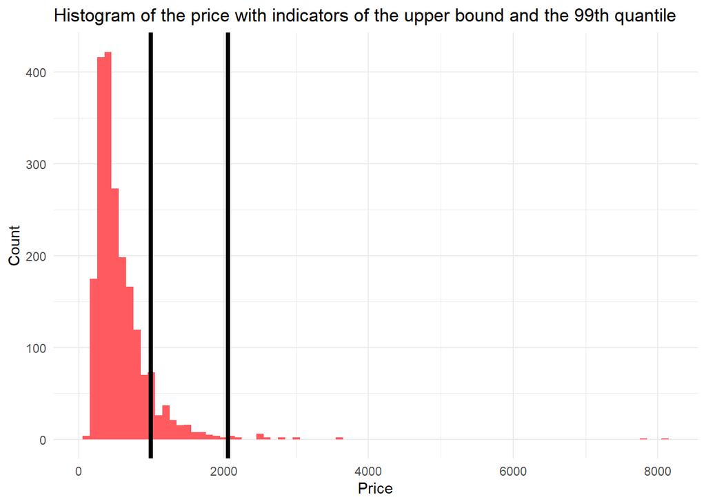

```r
# compute bounds for outliers and display the distribution of the price
ggplot(complete_data, aes(x = price)) +
  geom_histogram(binwidth = 100, fill = "#FF5A5F") +
  labs(x = "Price", y = "Count", title = "Histogram of the price with indicators of the upper bound and the 99th quantile") +
  theme_minimal() +
  geom_vline(xintercept  = upper_bound, size = 1.5) +
  geom_vline(xintercept  = quantile_99, size = 1.5)
```

#### Multivariate visualizations

For continuous features, there is calculated a non-linear correlation, as the linear one is smaller with values up to 0.25 between price and predictors. It can be observed that between the target and any other feature, the correlation is at most a medium one (positive or negative). Also, the distances and indices are almost perfectly correlated, meaning that some of them will not be that relevant to the model.

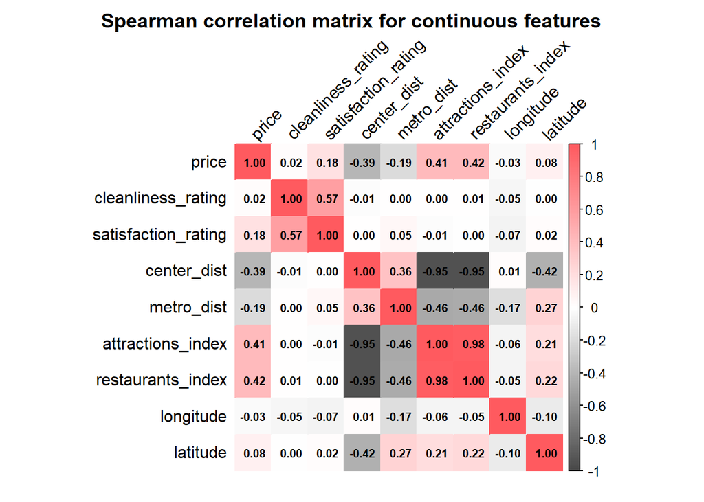

```r
corrplot(
  cor(continuous_data, method = "spearman"),
  method = "color",
  addCoef.col = "black",
  number.cex = 0.7,
  tl.col = "black",
  tl.srt = 45,
  mar = c(1, 1, 2, 1),
  title = "Spearman correlation matrix for continuous features",
  col = colorRampPalette(c("#484848", "#FFFFFF", "#FF5A5F"))(200)
)
```

When it comes to relationships between categorical features, mutual information was calculated. There is only one notable link between bedrooms_no and capacity.

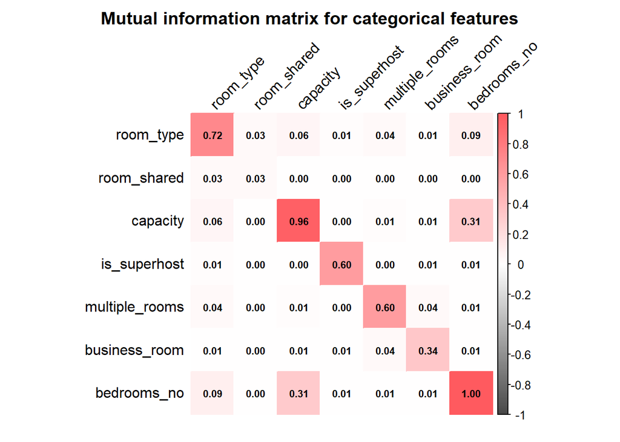

```r
mutual_information <- mutinformation(categorical_data)
mutual_information[mutual_information > 1] <- 1

corrplot(
  mutual_information,
  method = "color",
  addCoef.col = "black",
  number.cex = 0.7,
  tl.col = "black",
  tl.srt = 45,
  mar = c(1, 1, 2, 1),
  title = "Mutual information matrix for categorical features",
  col = colorRampPalette(c("#484848", "#FFFFFF", "#FF5A5F"))(200)
)
```

#### Bivariate visualizations

In this section we visualize relationships between variables.

Even though these indices are almost perfectly correlated, locations with an attractiveness index higher than ~40 do not have many restaurants around, with the maximum index for restaurants being below 75.

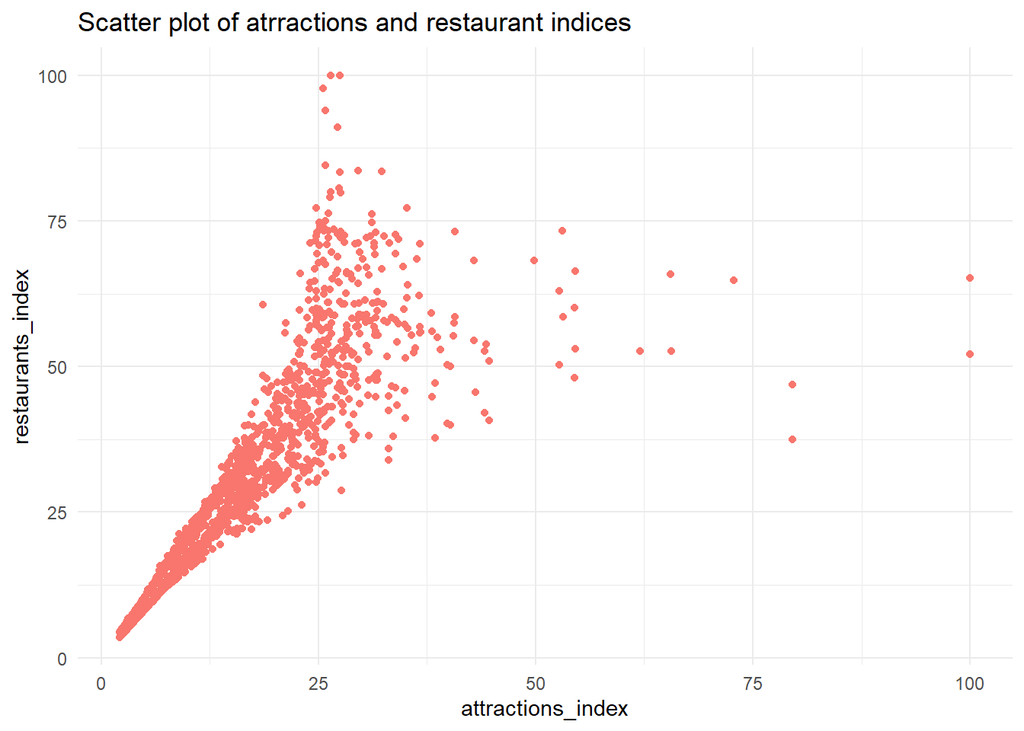

```r
ggplot(data,
       aes(
         x = attractions_index,
         y = restaurants_index,
         color = "#FF5A5F"
       )) +
  geom_point() +
  labs(title = "Scatter plot of atrractions and restaurant indices") +
  theme_minimal() +
  theme(legend.position = "none")
```

It can be seen below that for every degree of satisfaction above 80, the price spectrum is almost covered. Additionally, more expensive properties have higher ratings, which is expected.

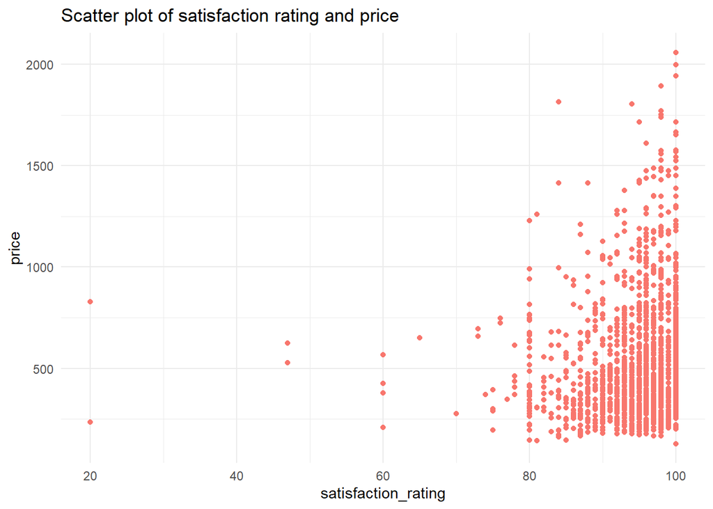

```r
ggplot(data, aes(
  x = satisfaction_rating,
  y = price,
  color = "#FF5A5F"
)) +
  geom_point() +
  labs(title = "Scatter plot of satisfaction rating and price") +
  theme_minimal() +
  theme(legend.position = "none")
```

For capacity and number of bedrooms, the median price tends to increase with the class of these two features.

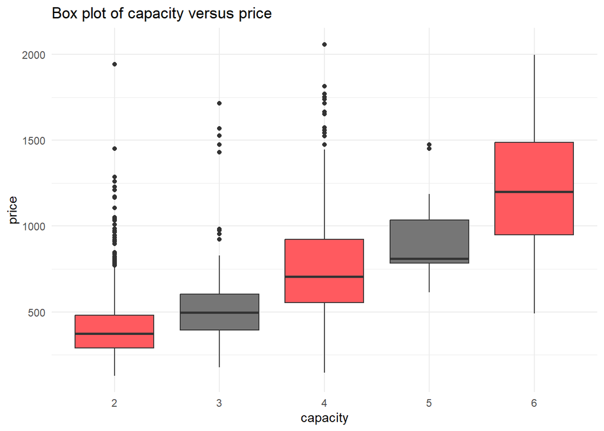

```r
ggplot(data, aes(x = capacity, y = price, fill = capacity)) +
  geom_boxplot() +
  labs(title = "Box plot of capacity versus price") +
  scale_fill_manual(values = c("#FF5A5F", "#767676", "#FF5A5F", "#767676", "#FF5A5F")) +
  theme_minimal() +
  theme(legend.position = "none")
```

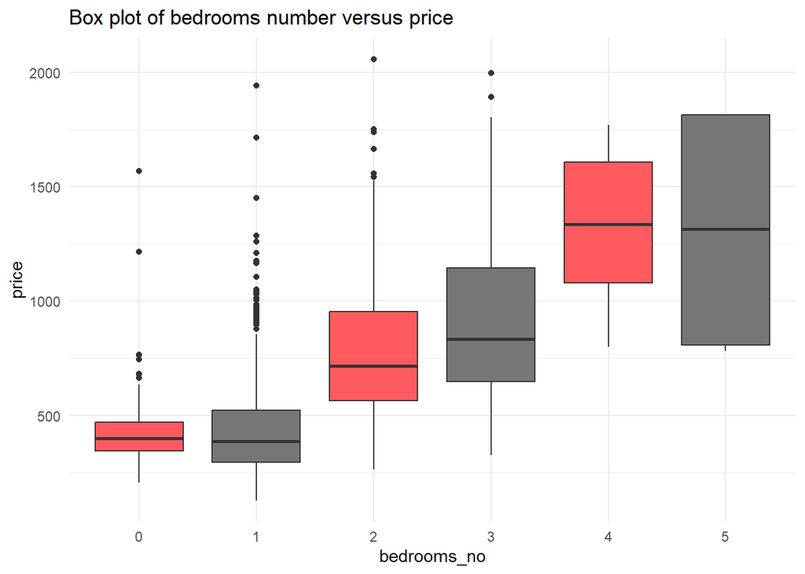

```r
ggplot(data, aes(x = bedrooms_no, y = price, fill = bedrooms_no)) +
  geom_boxplot() +
  labs(title = "Box plot of bedrooms number versus price") +
  scale_fill_manual(values = c(
    "#FF5A5F",
    "#767676",
    "#FF5A5F",
    "#767676",
    "#FF5A5F",
    "#767676"
  )) +
  theme_minimal() +
  theme(legend.position = "none")
```

Last but not least, the following map shows how the Airbnb price per night varies by location in Amsterdam, darker shades of red represent higher prices.

```r
leaflet() %>%
  setView(lng = 4.9, lat = 52.37, zoom = 11) %>%
  addProviderTiles(providers$CartoDB.Positron) %>%
  addHeatmap(
    lng = data$longitude,
    lat = data$latitude,
    intensity = data$price,
    radius = 10,
    blur = 2,
    max = 30,
    gradient = c("#FF5A5F", "#FF5A5F")
  )
```

[interactive chart not shown]

### Motivating model choice

Based on the exploratory analysis of the data, the chosen model is the Random Forest Regressor. This model was picked for several reasons:  
1. Pearson correlation showed that there is no linear relationship between the predictors and the target, so a model that can capture complex nonlinear relationships must be used.  
2. This model is interpretable, which is necessary in the context of a web application designed for end users.  
3. It is robust to outliers that were detected in several independent variables, such as center_dist, metro_dist, attractions_index, and restaurants_index.

### Feature selection

Before tuning the hyperparameters, we need to choose the best subset of features. To do this, the **recursive feature elimination** technique is used, which starts from the entire feature set and at each point removes the least significant feature until none remain. This method is applied together with a 10-fold cross-validation where the RMSE metric is minimized. There are used only 100 trees to speed-up the process.

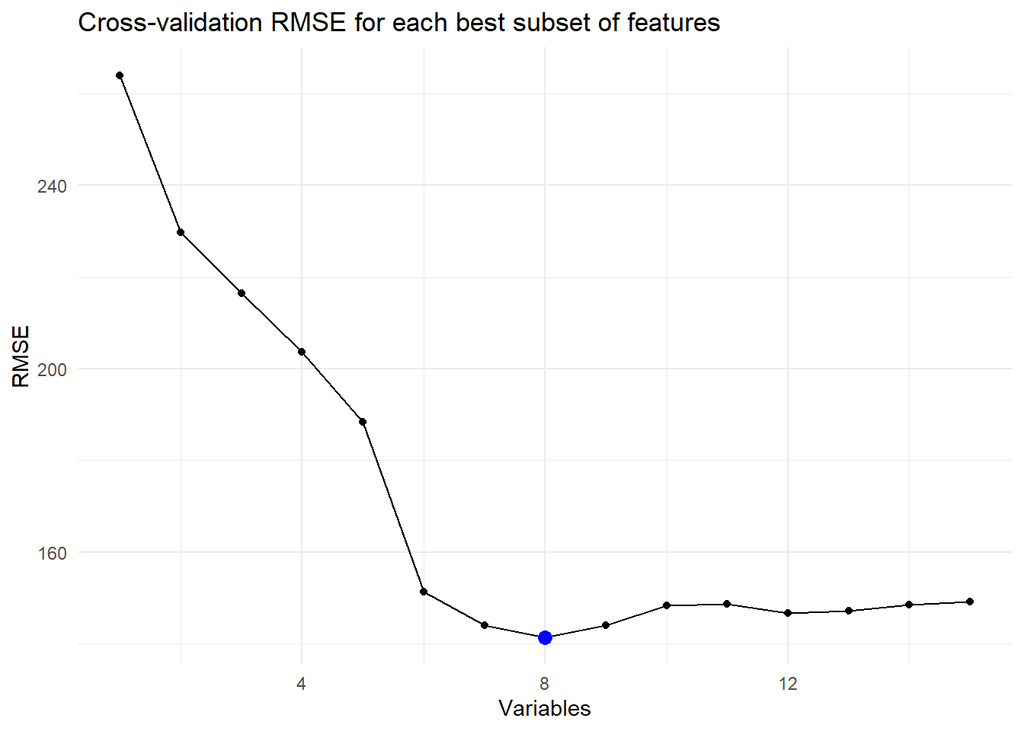

```r
# ensure results are reproducible
set.seed(19)

# set up the control parameters for recursive feature elimination (RFE)
control <- rfeControl(functions = rfFuncs,
                      method = "cv",
                      number = 10,
                      saveDetails = TRUE)

# perform recursive feature elimination
rfe_results <- rfe(
  x = data[, !colnames(data) %in% "price", drop = FALSE],
  y = data[["price"]],
  method = "rf",
  metric = "RMSE",
  sizes = seq(1:ncol(data)),
  rfeControl = control,
  ntree = 100
)

# show the results of RFE
ggplot(data = rfe_results, metric = "RMSE") +
  theme_minimal() +
  labs(title = "Cross-validation RMSE for each best subset of features", x = "Variables", y = "RMSE")
```

```r
# measured metrics for each subset of features
rfe_results$results
```

| Variables | RMSE | Rsquared | MAE | RMSESD | RsquaredSD | MAESD |
| --- | --- | --- | --- | --- | --- | --- |
| 1 | 264.0396 | 0.2563085 | 188.48753 | 28.39392 | 0.05218128 | 14.147093 |
| 2 | 229.7880 | 0.4433331 | 160.21775 | 24.41437 | 0.05793345 | 11.115290 |
| 3 | 216.4676 | 0.5092051 | 152.71593 | 23.50608 | 0.05915636 | 11.462987 |
| 4 | 203.7179 | 0.5730591 | 144.20434 | 22.95135 | 0.06824578 | 10.125486 |
| 5 | 188.4031 | 0.6411451 | 131.60780 | 19.26900 | 0.06090909 | 7.875011 |
| 6 | 151.2419 | 0.7603011 | 102.44065 | 20.87288 | 0.04857468 | 6.129979 |
| 7 | 144.0493 | 0.7818160 | 95.56707 | 21.52124 | 0.05192916 | 7.470674 |
| 8 | 141.4195 | 0.7919941 | 93.04266 | 22.05006 | 0.04851038 | 7.756194 |
| 9 | 143.9649 | 0.7813357 | 94.10567 | 23.66120 | 0.05616185 | 9.709994 |
| 10 | 148.3249 | 0.7699635 | 97.91292 | 20.16749 | 0.04789565 | 7.414089 |

[output cut: 5 more lines]

Get only the selected features from the dataset and store this version of the dataset for later use in the Shiny application.

```r
# get the selected features
selected_features_list <- c()

for (feature in colnames(data)) {
  for (important_feature in predictors(rfe_results)) {
    if (grepl(feature, important_feature)) {
      selected_features_list <- append(selected_features_list, feature)
      break
    }
  }
}

# get only the selected features and store the filtered dataset for further use
selected_features_list <- append(selected_features_list, "price")
data <- data[, selected_features_list]
write.csv(data, file = "./airbnb_price_prediction/www/amsterdam_preprocessed.csv", row.names = FALSE)
data
```

| room_type | capacity | satisfaction_rating | bedrooms_no | metro_dist | attractions_index | longitude | latitude | price |
| --- | --- | --- | --- | --- | --- | --- | --- | --- |
| Private room | 2 | 93 | 1 | 2.53938000 | 4.166708 | 4.90569 | 52.41772 | 194.0337 |
| Private room | 4 | 85 | 1 | 0.23940392 | 33.421209 | 4.90005 | 52.37432 | 344.2458 |
| Private room | 2 | 87 | 1 | 3.65162129 | 3.985908 | 4.97512 | 52.36103 | 264.1014 |
| Private room | 4 | 90 | 2 | 0.43987608 | 26.119108 | 4.89417 | 52.37663 | 433.5294 |
| Private room | 2 | 98 | 1 | 0.31869265 | 29.272733 | 4.90051 | 52.37508 | 485.5529 |
| Private room | 3 | 100 | 2 | 1.90466824 | 9.255191 | 4.87699 | 52.38966 | 552.8086 |
| Private room | 2 | 94 | 1 | 0.72974674 | 10.599010 | 4.91570 | 52.38296 | 215.1243 |
| Entire home/apt | 4 | 96 | 2 | 1.19611235 | 5.624761 | 4.86459 | 52.40175 | 1001.8044 |
| Private room | 2 | 88 | 1 | 0.92440444 | 10.921226 | 4.87600 | 52.34700 | 276.5215 |
| Entire home/apt | 2 | 96 | 1 | 0.91711507 | 21.702260 | 4.87956 | 52.36953 | 909.4744 |

[output cut: 2049 more lines]

### Modeling

#### Tuning

In this step, we use a 5-fold cross-validation to optimize two hyperparameters of the Random Forest model. The optimized metric is RMSE and the search space is represented by:  
- mtry: number of features randomly sampled as candidates at each split  
- ntree: number of trees (we do not try to train too many trees as in the research paper [How many trees in a random forest?](https://link.springer.com/chapter/10.1007/978-3-642-31537-4_13) it has been shown that having more than 128 decision trees does not bring much benefit.)

```r
# tune the hyperparameters
optimization_control <- trainControl(method = 'cv', number = 5)
number_of_features <- ncol(data)

mtry_values <- c(number_of_features - 1,
                 round(sqrt(number_of_features - 1)),
                 round((number_of_features - 1)/ 3))

ntree_values <- c(64, 100, 128, 200)
best_rmse <- .Machine$integer.max

for (ntree_value in ntree_values) {
    rf_optimized <- train(
      price ~ .,
      data = data,
      method = 'rf',
      metric = 'RMSE',
      ntree = ntree_value,
      tuneGrid = expand.grid(.mtry = mtry_values),
      trControl = optimization_control
    )

    rmse <- min(rf_optimized$results$RMSE)

    if (best_rmse > rmse) {
      best_rmse <- rmse
      best_rf_optimized <- rf_optimized$finalModel
    }
}

paste("The best RMSE value is", round(best_rmse, 2), "obtained with mtry", best_rf_optimized$mtry, "and", best_rf_optimized$ntree, "trees.")
```

```
## [1] "The best RMSE value is 141.05 obtained with mtry 8 and 200 trees."
```

### Final Model

Next we train the final model on the entire dataset with the found hyperparameters. As performance metrics we use the **coefficient of determination**, the **root mean squared error** and the **mean absolute error** because we want to have different perspectives on the model’s performance.

```r
# get the best params and re-fit the model on the whole dataset, then save it
rf_final_model <- randomForest(
  price ~.,
  data = data,
  importance = TRUE,
  mtry = best_rf_optimized$mtry,
  ntree = best_rf_optimized$ntree,
)

predictions <- predict(rf_final_model, newdata = data)
MAE <- mean(abs(data$price - predictions))
Rsq <- cor(data$price, predictions)^2
RMSE <- sqrt(mean((data$price - predictions)^2))

cat(paste("R^2 final model:", round(Rsq, 2), "\n", "MAE final model:", round(MAE, 2), "\n", " RMSE final model:", round(RMSE, 2)))
```

```
## R^2 final model: 0.97
##  MAE final model: 36.63
##   RMSE final model: 57.86
```

After that we check the importance of the features and store the final model that will be used in the Shiny application. By scaling the feature importance such that their sum is 100, it can be seen that each has an importance of at least 5%, with **no_bedrooms** and **attraction_index** being the most impactful for price, which makes sense in the context of tourism.

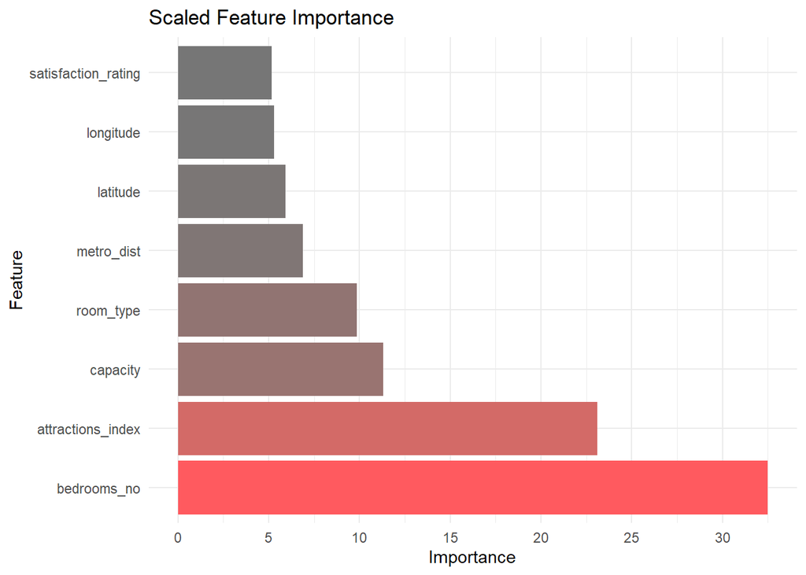

```r
plot_feature_importance <- function(rf_model) {
  # build the feature importance plot given by the model on the entire dataset
  feature_importance <- as.data.frame(importance(rf_model)) %>%
    rename("importance" = "IncNodePurity")
  feature_importance$importance  <- feature_importance$importance / sum(feature_importance$importance) * 100
  feature_importance <- feature_importance %>% arrange(desc(importance))

  ggplot(feature_importance,
         aes(
           x  = rownames(feature_importance),
           y = importance,
           fill = importance
         )) +
    geom_bar(stat = "identity") +
    scale_fill_gradient(low = "#767676", high = "#FF5A5F") +
    labs(title = "Scaled Feature Importance", x = "Feature", y = "Importance") +
    theme_minimal() +
    guides(fill = "none") +
    scale_y_continuous(breaks = seq(0, 100, by = 5),
                       labels = seq(0, 100, by = 5),) +
    scale_x_discrete(limits = rownames(feature_importance)) +
    coord_flip()
}

# store the final Random Forest model
saveRDS(rf_final_model, file = "./airbnb_price_prediction/www/rf_model.rds")
plot_feature_importance(rf_final_model)
```

### Validation

Finally, we validate the model using two techniques.

#### Cross-validation

We leverage a 5-fold cross-validation applied 30 times (which is the minimum sample size [accepted by the scientific community](https://pmc.ncbi.nlm.nih.gov/articles/PMC7745163/)) to compute afterwards the confidence interval for each of the three measured metrics. These intervals are narrow, so the model is fairly stable from one cross-validation repetition to another.

```r
# compute the confidence interval based on repeated cross-validation
cv_control <- caret::trainControl(
  method = "repeatedcv",
  number = 5,
  repeats = 30,
  savePredictions = TRUE
)

rf_cv_results <- caret::train(
  price ~ .,
  data = data,
  method = "rf",
  metric = "RMSE",
  tuneGrid = expand.grid(.mtry = c(best_rf_optimized$mtry)),
  ntree = best_rf_optimized$ntree,
  trControl = cv_control
)

# get the average metrics value for each repetition out of the 30
agg_metrics <- subset(
  rf_cv_results$resample %>%
    mutate(Repetition = str_sub(Resample, start = 7)) %>%
    group_by(Repetition) %>%
    summarize(across(everything(), ~ mean(.x))),
  select = -c(Resample)
)

cat(
  paste(
    "R^2 95% confidence interval:",
    round(quantile(agg_metrics$Rsquared, 0.025), 2),
    round(mean(agg_metrics$Rsquared), 2),
    round(quantile(agg_metrics$Rsquared, 0.975), 2),
    "\n",
    "MAE 95% confidence interval:",
    round(quantile(agg_metrics$MAE, 0.025), 2),
    round(mean(agg_metrics$MAE), 2),
    round(quantile(agg_metrics$MAE, 0.975), 2),
    "\n",
    " RMSE 95% confidence interval:",
    round(quantile(agg_metrics$RMSE, 0.025), 2),
    round(mean(agg_metrics$RMSE), 2),
    round(quantile(agg_metrics$RMSE, 0.975), 2)
  )
)
```

```
## R^2 95% confidence interval: 0.76 0.78 0.79
##  MAE 95% confidence interval: 92.09 93.71 96.43
##   RMSE 95% confidence interval: 140.63 144.28 151.05
```

For more insights, we plot the residuals obtained on the test folds over one cross-validation iteration. It can be seen that the model does not predict prices higher than 1,600 euros, even though the train data contains values up to 2,000. This occurs because values greater than the upper limit defined using the interquartile range are underrepresented. Additionally, the variance around the 0-axis appears to be increasing, meaning that for higher prices the model makes more mistakes. However, there are no visible patterns and the data appears to be randomly scattered around the horizontal 0 axis, which is a sign that the model has learned the data correctly.

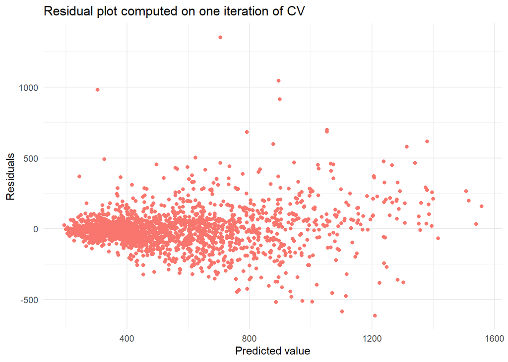

```r
# store the cross-validation results
saveRDS(rf_cv_results, file = "./airbnb_price_prediction/www/rf_cv_results.rds")

pred_obs <- rf_cv_results$pred %>%
  dplyr::filter(str_sub(Resample, start = 7, end = 11) == "Rep01")

ggplot(pred_obs, aes(
  x = pred,
  y = obs - pred,
  color = "#FF5A5F"
)) +
  geom_point() +
  labs(x = "Predicted value", y = "Residuals", title = "Residual plot computed on one iteration of CV") +
  theme_minimal() +
  theme(legend.position = "none")
```

#### Bootstrap validation

For this validation technique we create 30 data samples and calculate the optimism-adjusted RMSE value. It can be seen that the value obtained is slightly lower than that obtained by using cross-validation, but quite similar. Therefore, we can conclude that the validation techniques lead to the same conclusion.

```r
bootstap_validation <- function(data, index, all_features) {
  # get the bootstrap sample
  bootstrap_data <- data[index, ]

  # train the model on the bootstrap data
  boot_rf_model <- randomForest(
    price ~ .,
    data = bootstrap_data,
    mtry = best_rf_optimized$mtry,
    ntree = best_rf_optimized$ntree,
  )

  # predict on the bootstrap dataset and compute the RMSE
  predictions <- predict(boot_rf_model, newdata = bootstrap_data)
  RMSE_b_bootstrap <- sqrt(mean((bootstrap_data$price - predictions) ^ 2))

  # predict on the entire dataset and compute the RMSE
  predictions <- predict(boot_rf_model, newdata = data)
  RMSE_b_orig <- sqrt(mean((data$price - predictions) ^ 2))

  return (c(
    RMSE_b_bootstrap,
    RMSE_b_orig,
    RMSE_b_bootstrap - RMSE_b_orig
  ))
}

# compute the optimism-adjusted RMSE
boot_data <- boot(data, bootstap_validation, R = 30)
colnames(boot_data$t) <- c("RMSE_b_boot", "RMSE_b_orig", "RMSE_optimism")
boot_validation_metrics <- colMeans(boot_data$t)
paste("Optimism-adjusted RMSE:",  round(RMSE - boot_validation_metrics[3], 2))
```

```
## [1] "Optimism-adjusted RMSE: 117.55"
```

### Conclusion and future improvements

In conclusion, we found the **eigth most relevant features** for estimating the nightly rental price of an Airbnb in Amsterdam and trained and validated a **performant Random Forest** model that will be used in a Shiny application by owners who want to check the relationship between price and a possible satisfaction rating given by users for their property. As future improvements, similar analyses can be developed for other European cities and more complex models such as XGBoost tested.

The Shiny application can be found [here](https://mihai-bogdan-bindila.shinyapps.io/airbnb-price-prediction/).